# Price Classification Analysis for Airbnb Listings in Sydney, Australia

STAT5003 - Computational Statistical Methods Semester 2 2025

Group Number: W14_G03 Student IDs: 550217239, 550232025, 540989498, 540958494, 550300357

Date: 21 September 2025

# 1 Executive Summary

This report explores the pricing dynamics of Airbnb listings in Sydney by utilising machine learning classification models to predict Sydney property price categories Budget (<$100), Mid-Market ($100-$200) and Premium (>$200) using property characteristics, location data and host information. Our analysis addresses key Australian housing market challenges while providing actionable insights for tourism and rental property sectors. We begin analysis with detailed data cleaning such as formatting, handling missing values and addressing outliers. EDA performed on the dataset highlights geographic clustering of premium properties around Sydney Harbour and CBD, while budget options are more spread towards outer suburbs. Overall, this study demonstrates how data-driven classification can uncover meaningful patterns in Airbnb pricing, supporting more informed decision-making across the platform’s ecosystem.

# 2 Problem Definition

## 2.1 Research Question

Can we predict whether a Sydney Airbnb property will be classified as Premium (>$200/night), Mid-Market ($100-200/night), or Budget (<$100/night) based on property characteristics, location and host factors?

## 2.2 Classification Problem Framework

This project focuses on a multi-class classification problem with three distinct target categories:

- **Premium**: Properties >$200/night (luxury market segment)
- **Mid-Market**: Properties $100-200/night (mainstream market)
- **Budget**: Properties <$100/night (budget-conscious travelers)

The classification approach enables predictive insights for property investors, market segmentation analysis for tourism planning and guiding in pricing strategy guidance for potential hosts.

# 3 Data Description

The Sydney Airbnb Listings dataset contains detailed information on over 18,000 listings across the city, with approximately 79 variables describing property characteristics, host details, geographic location, availability and customer engagement. Key attributes include listing identifiers, host information, neighbourhoods, room type, number of reviews, minimum nights, availability and pricing. For the purpose of this study, the focus is on the price variable, which has been cleaned to remove formatting and extreme outliers, and subsequently transformed into a categorical target variable representing three market segments (Inside Airbnb, 2025; Cox, 2024).

**Show/Hide Code & Results**

```r
# Load required libraries
library(tidyverse)      # Data manipulation and visualization
library(VIM)           # Missing data visualization
```

```r
library(corrplot)      # Correlation plots
library(ggplot2)       # Advanced plotting
library(dplyr)         # Data manipulation
library(readr)         # Reading CSV files
library(stringr)       # String manipulation
library(plotly)        # Interactive plots
library(gridExtra)     # Multiple plots
library(scales)        # Scale formatting
library(knitr)         # Table formatting
library(DT)            # Interactive tables
```

## 3.1 Data Source

**Primary Dataset:** Inside Airbnb Sydney Listings

**Reference:** Inside Airbnb. (2025). Sydney, New South Wales, Australia Dataset. Retrieved from http://insideairbnb.com/get-the-data/. Data sourced from publicly available information from Airbnb.com. Murray Cox, Inside Airbnb Project.

**Data Collection Method:** Web scraping of publicly available Airbnb listing information

**Data Currency:** Most recent quarterly snapshot available (2025)

**Show/Hide Code & Results**

```r
# Load and examine the dataset
listings_raw <- read_csv("listings.csv")
# Replace all "N/A" values with blank in character columns
char_cols <- names(listings_raw)[sapply(listings_raw, is.character)]
for(col in char_cols) {
  listings_raw[[col]][listings_raw[[col]] == "N/A"] <- ""
}

# Define variables
dims <- paste(dim(listings_raw), collapse = " x ")
nvars <- ncol(listings_raw)


# Print all in one cat
cat(" Full dataset dimensions:", dims, "\n", "Total variables available:", nvars, "\n")
```

```
##  Full dataset dimensions: 18187 x 79
##  Total variables available: 79
```

## 3.2 Feature Selection Strategy

Given the comprehensive nature of the Inside Airbnb dataset (18187 listings x 79 features), we employ a strategic feature selection approach focusing on variables most relevant to pricing classification.

**Show/Hide Code & Results**

```r
# FEATURE SELECTION: Selecting the most relevant variables for classification
selected_features <- c(
  "id", "price", "property_type", "room_type", "accommodates",
  "bedrooms", "bathrooms", "amenities", "neighbourhood_cleansed",
  "latitude", "longitude", "host_is_superhost", "host_response_rate",
  "host_listings_count", "host_identity_verified", "review_scores_rating",
  "number_of_reviews", "reviews_per_month", "availability_365",
  "minimum_nights"
)
```

## 3.3 Dataset Overview

**Show/Hide Code & Results**

```r
# Basic dataset information
listings_raw <- listings_raw %>%
  mutate(across(where(~ all(. %in% c("t", "f"))), ~.=="t"))
# Selected only the chosen features
listings <- listings_raw %>%
  select(all_of(selected_features))


# Variable types
numeric_vars <- listings %>% select_if(is.numeric) %>% names()
character_vars <- listings %>% select_if(is.character) %>% names()
boolean_vars <- listings %>% select_if(is.logical) %>% names()



cat(" DATASET SUMMARY:\n", "Number of observations:", nrow(listings), ", Number of variables:", ncol(listings), "\n", "\n VARIABLE TYPES:\n", "Numeric variables (", length(numeric_vars), "):", paste(numeric_vars, collapse = ", "), "\n","Character variables (", length(character_vars), "):", paste(character_vars, collapse = ", "), "\n", "Boolean variables (", length(boolean_vars), "):", paste(boolean_vars, collapse = ", "), "\n")
```

```
##  DATASET SUMMARY:
##  Number of observations: 18187 , Number of variables: 20
##
##  VARIABLE TYPES:
##  Numeric variables ( 12 ): id, accommodates, bedrooms, bathrooms, latitude, longitude, host_listings_count, review_scores_rating, number_of_reviews, reviews_per_month, availability_365, minimum_nights
##  Character variables ( 6 ): price, property_type, room_type, amenities, neighbourhood_cleansed, host_response_rate
##  Boolean variables ( 2 ): host_is_superhost, host_identity_verified
```

## 3.4 Target Variable Creation

To simplify classfication processs, the continuous target variable Price was transformed into a categorical outcome representing distinct market segments. Raw price values, originally stored as character strings with currency symbols and commas were first cleaned and converted into numeric format. Extreme outliers such as nightly rates in higher ranges were excluded to reduce noise and improve model stability.

**Show/Hide Code & Results**

```r
# Creating target variable based on price thresholds

# Cleaning price data
listings$price_numeric <- as.numeric(gsub("[$,]", "", listings$price))

# Creating price categories
listings$price_category <- cut(
  listings$price_numeric,
  breaks = c(0, 100, 200, Inf),
  labels = c("Budget", "Mid-Market", "Premium"),
  include.lowest = TRUE
)

# Summaries
price_summary <- summary(listings$price_numeric)
target_dist <- table(listings$price_category)
target_props <- prop.table(target_dist) * 100


cat(
  "CREATING TARGET VARIABLE:\n\n",
  "PRICE SUMMARY (in $ per night):\n",
  sprintf("Min       : %.2f\n", price_summary["Min."]),
  sprintf("1st Qu.   : %.2f\n", price_summary["1st Qu."]),
  sprintf("Median    : %.2f\n", price_summary["Median"]),
  sprintf("Mean      : %.2f\n", price_summary["Mean"]),
  sprintf("3rd Qu.   : %.2f\n", price_summary["3rd Qu."]),
  sprintf("Max       : %.2f\n\n", price_summary["Max."]),
  "TARGET VARIABLE DEFINITION:\n",
  "- Budget      : $0-100/night (Budget-conscious travelers)\n",
  "- Mid-Market  : $100-200/night (Mainstream market)\n",
  "- Premium     : >$200/night (Luxury segment)\n\n",
  "TARGET VARIABLE DISTRIBUTION:\n",
  sprintf("Budget      : %d (%.2f%%)\n", target_dist["Budget"], target_props["Budget"]),
  sprintf("Mid-Market  : %d (%.2f%%)\n", target_dist["Mid-Market"], target_props["Mid-Market"]),
  sprintf("Premium     : %d (%.2f%%)\n", target_dist["Premium"], target_props["Premium"]),
  sprintf("NaN values  : %d \n", (18187-(target_dist["Budget"]+target_dist["Mid-Market"]+target_dist["Premium"]))),
  sep = ""
)
```

```
## CREATING TARGET VARIABLE:
##
## PRICE SUMMARY (in $ per night):
## Min       : 17.00
## 1st Qu.   : 139.00
## Median    : 206.00
## Mean      : 339.47
## 3rd Qu.   : 329.00
## Max       : 20000.00
##
## TARGET VARIABLE DEFINITION:
## - Budget      : $0-100/night (Budget-conscious travelers)
## - Mid-Market  : $100-200/night (Mainstream market)
## - Premium     : >$200/night (Luxury segment)
##
## TARGET VARIABLE DISTRIBUTION:
## Budget      : 2181 (13.86%)
## Mid-Market  : 5433 (34.53%)
## Premium     : 8120 (51.61%)
## NaN values  : 2453
```

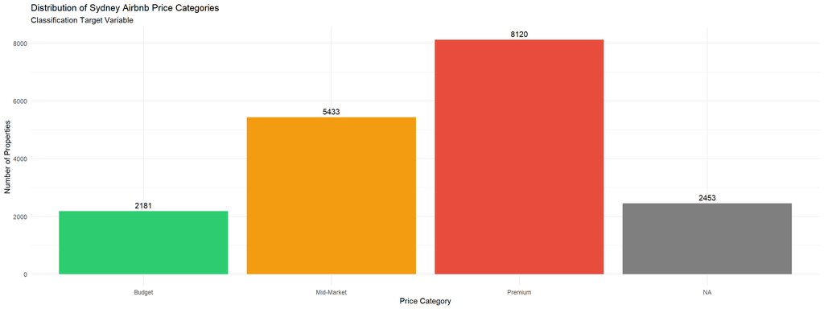

```r
# Bar Plot for Price vs Number of Properties
ggplot(listings, aes(x = price_category, fill = price_category)) +
  geom_bar() +
  geom_text(stat = 'count', aes(label = ..count..), vjust = -0.5) +
  labs(title = "Distribution of Sydney Airbnb Price Categories",
       subtitle = "Classification Target Variable",
       x = "Price Category", y = "Number of Properties") +
  theme_minimal() +
  scale_fill_manual(values = c("Budget" = "#2ecc71", "Mid-Market" = "#f39c12", "Premium" = "#e74c3c")) +
  theme(legend.position = "none")
```

# 4 Data Cleaning and Preparation

The raw dataset required extensive cleaning and preprocessing to ensure reliability for data analysis and modeling using classification algorithms. Non-numeric entries in the price field were removed before converting the variable values to numeric ones. Character columns containing N/A values were standardized by imputation using median strategy or by replacing with minimum values (0, 1, FALSE). The cleaned dataset provided a complete and consistent foundation with a refined set of features suitable for exploratory analysis and predictive modeling (Michelucci, 2025).

## 4.1 Data Preparation

**Show/Hide Code & Results**

```r
output_str <- ""

# 1. Missing values analysis
missing_summary <- listings %>%
  summarise_all(~sum(is.na(.))) %>%
  gather(variable, missing_count) %>%
  mutate(missing_percent = round(missing_count / nrow(listings) * 100, 2)) %>%
  filter(missing_count > 0) %>%
  arrange(desc(missing_percent))

if(nrow(missing_summary) > 0) {
  output_str <- paste0(output_str, "1. Missing Values Detected:\n")
  output_str <- paste0(output_str, "Number of missing columns: ", nrow(missing_summary), "\n")

  # Create formatted strings for each variable
  missing_strings <- paste0(missing_summary$variable, ": ",
                           missing_summary$missing_count, " (",
                           missing_summary$missing_percent, "%)")

  # Join all with | separator
  output_str <- paste0(output_str, paste(missing_strings, collapse = " | "), "\n")
} else {
  output_str <- paste0(output_str, "1. Missing Values: No missing values detected in selected features\n")
}

# 2. Price outliers
price_outliers <- listings %>%
  filter(price_numeric > quantile(price_numeric, 0.99, na.rm = TRUE) |
         price_numeric < quantile(price_numeric, 0.01, na.rm = TRUE)) %>%
  nrow()
output_str <- paste0(output_str, "\n2. Price Outliers:\n")
output_str <- paste0(output_str, "Potential price outliers (beyond 1st/99th percentile): ", price_outliers, "\n")

# 3. Categorical variable complexity
output_str <- paste0(output_str, "\n3. High-Dimensional Categorical Data:\n")
output_str <- paste0(output_str, "Number of unique neighbourhoods: ", length(unique(listings$neighbourhood_cleansed)), "\n")
output_str <- paste0(output_str, "Number of unique property types: ", length(unique(listings$property_type)), "\n")

# 4. Class imbalance
min_class_prop <- min(prop.table(table(listings$price_category)))
max_class_prop <- max(prop.table(table(listings$price_category)))
imbalance_ratio <- max_class_prop / min_class_prop
output_str <- paste0(output_str, "\n4. Class Imbalance Analysis:\n")
output_str <- paste0(output_str, "Class imbalance ratio: ", round(imbalance_ratio, 2), ":1\n")

# 5. Additional challenges that can be considered
output_str <- paste0(output_str, "\n5. Additional Challenges that can be consideredD:\n")
output_str <- paste0(output_str, "- Geographic clustering effects in Sydney neighborhoods\n")
output_str <- paste0(output_str, "- Seasonal pricing variations not captured in snapshot data\n")
output_str <- paste0(output_str, "- Text processing requirements for amenities field\n")
output_str <- paste0(output_str, "- Potential correlation between location and property characteristics\n")

cat(output_str)
```

```
## 1. Missing Values Detected:
## Number of missing columns: 11
## review_scores_rating: 3179 (17.48%) | reviews_per_month: 3179 (17.48%) | bathrooms: 2458 (13.52%) | price: 2453 (13.49%) | price_numeric: 2453 (13.49%) | price_category: 2453 (13.49%) | host_is_superhost: 556 (3.06%) | bedrooms: 436 (2.4%) | host_response_rate: 5 (0.03%) | host_listings_count: 5 …
##
## 2. Price Outliers:
## Potential price outliers (beyond 1st/99th percentile): 301
##
## 3. High-Dimensional Categorical Data:
## Number of unique neighbourhoods: 38
## Number of unique property types: 69
##
## 4. Class Imbalance Analysis:
## Class imbalance ratio: 3.72:1
##
## 5. Additional Challenges that can be consideredD:
## - Geographic clustering effects in Sydney neighborhoods
## - Seasonal pricing variations not captured in snapshot data
## - Text processing requirements for amenities field
## - Potential correlation between location and property characteristics
```

## 4.2 Data Cleaning

**Show/Hide Code & Results**

```r
output_text <- ""

# Initial data dimensions
initial_dim <- dim(listings)
output_text <- paste0(output_text, "Initial data dimensions: ", initial_dim[1], " rows x ", initial_dim[2], " columns\n\n")

# 1. Handling price data
listings$price_numeric <- as.numeric(gsub("[$,]", "", listings$price))
outlier_threshold <- 1000
initial_count <- nrow(listings)
listings <- listings %>% filter(price_numeric > 0 & price_numeric <= outlier_threshold)
removed_outliers <- initial_count - nrow(listings)
output_text <- paste0(output_text, "Removed ", removed_outliers, " extreme price outliers (>$", outlier_threshold, ")\n")
output_text <- paste0(output_text, "Remaining observations: ", nrow(listings), "\n\n")

# 2. Clean host_is_superhost
listings$host_is_superhost <- ifelse(listings$host_is_superhost == "t", TRUE, FALSE)

# 3. Handle host_response_rate
if("host_response_rate" %in% names(listings)) {
  listings$host_response_rate <- as.numeric(gsub("%", "", listings$host_response_rate)) / 100
}

# 4. Process amenities
if("amenities" %in% names(listings)) {
  listings$amenities_count <- ifelse(
    is.na(listings$amenities) | listings$amenities == "" | listings$amenities == "[]",
    0,
    str_count(listings$amenities, '",') + 1
  )
} else {
  listings$amenities_count <- 0
}

# 5. Handle missing values
missing_summary <- listings %>%
  summarise_all(~sum(is.na(.))) %>%
  gather(variable, missing_count) %>%
  mutate(missing_percent = round(missing_count / nrow(listings) * 100, 2)) %>%
  filter(missing_count > 0) %>%
  arrange(desc(missing_percent))

if(nrow(missing_summary) > 0) {
  for(i in 1:nrow(missing_summary)) {
    output_text <- paste0(output_text, sprintf("- %s: %d missing (%.2f%%)\n",
                                               missing_summary$variable[i],
                                               missing_summary$missing_count[i],
                                               missing_summary$missing_percent[i]))
  }
  output_text <- paste0(output_text, "\n")

  # Imputation
  if("reviews_per_month" %in% missing_summary$variable) {
    listings$reviews_per_month[is.na(listings$reviews_per_month)] <- 0
  }
  if("host_is_superhost" %in% missing_summary$variable) {
    listings$host_is_superhost[is.na(listings$host_is_superhost)] <- FALSE
  }
  if("bathrooms" %in% missing_summary$variable) {
    median_bathrooms <- median(listings$bathrooms, na.rm = TRUE)
    listings$bathrooms[is.na(listings$bathrooms)] <- median_bathrooms
  }
  if("host_listings_count" %in% missing_summary$variable) {
    listings$host_listings_count[is.na(listings$host_listings_count)] <- 1
  }
  if("host_identity_verified" %in% missing_summary$variable) {
    listings$host_identity_verified[is.na(listings$host_identity_verified)] <- FALSE
  }
  if("bedrooms" %in% missing_summary$variable) {
    listings$bedrooms[is.na(listings$bedrooms)] <- ceiling(listings$accommodates[is.na(listings$bedrooms)] / 2)
  }
  if("review_scores_rating" %in% missing_summary$variable) {
    median_rating <- median(listings$review_scores_rating, na.rm = TRUE)
    listings$review_scores_rating[is.na(listings$review_scores_rating)] <- median_rating
  }
  if("host_response_rate" %in% missing_summary$variable) {
    median_response_rate <- median(listings$host_response_rate, na.rm = TRUE)
    listings$host_response_rate[is.na(listings$host_response_rate)] <- median_response_rate
  }
} else {
  output_text <- paste0(output_text, "5. Handling missing values... No missing values detected after initial cleaning\n")
}

# Verify missing values
missing_after <- listings %>%
  summarise_all(~sum(is.na(.))) %>%
  gather(variable, missing_count) %>%
  filter(missing_count > 0)

if(nrow(missing_after) > 0) {
  output_text <- paste0(output_text, "\nVERIFYING IMPUTATION RESULTS:\n  Still have missing values in:\n")
  for(i in 1:nrow(missing_after)) {
    output_text <- paste0(output_text, sprintf("- %s: %d missing\n",
                                               missing_after$variable[i],
                                               missing_after$missing_count[i]))
  }
} else {
  output_text <- paste0(output_text, "\nVERIFYING IMPUTATION RESULTS:\n All missing values successfully handled!\n")
}

output_text <- paste0(output_text, " Missing data imputation strategy completed.\n\n")

# 6. Feature engineering
listings <- listings %>%
  mutate(
    is_popular_area = neighbourhood_cleansed %in% c("Bondi", "Sydney", "Manly", "Darlinghurst", "Surry Hills"),
    distance_from_cbd = sqrt((latitude - (-33.8688))^2 + (longitude - 151.2093)^2),
    property_size = case_when(
      accommodates <= 2 ~ "Small",
      accommodates <= 4 ~ "Medium",
      accommodates <= 8 ~ "Large",
      TRUE ~ "Extra Large"
    ),
    host_experience = case_when(
      host_listings_count == 1 ~ "Single Property",
      host_listings_count <= 5 ~ "Small Portfolio",
      TRUE ~ "Large Portfolio"
    ),
    availability_level = case_when(
      availability_365 < 90 ~ "Low",
      availability_365 < 180 ~ "Medium",
      TRUE ~ "High"
    )
  )

# 7. Remove duplicates
initial_rows <- nrow(listings)
listings <- listings %>% distinct()
duplicates_removed <- initial_rows - nrow(listings)

# Recreate target variable
listings$price_category <- cut(listings$price_numeric,
                               breaks = c(0, 100, 200, Inf),
                               labels = c("Budget", "Mid-Market", "Premium"),
                               include.lowest = TRUE)

# Final dataset summary
final_dim <- dim(listings)
final_target_dist <- table(listings$price_category)
final_target_prop <- round(prop.table(final_target_dist), 3)

output_text <- paste0(output_text, "Final Cleaned Dataset:\nDimensions: ", final_dim[1], " rows x ", final_dim[2], " columns\n")
output_text <- paste0(output_text, "Complete cases: ", sum(complete.cases(listings)), "\n\n")
output_text <- paste0(output_text, "Final target distribution:\n")
for(level in names(final_target_dist)) {
  output_text <- paste0(output_text, sprintf("%-10s : %d (%.3f)\n", level, final_target_dist[level], final_target_prop[level]))
}


cat(output_text)
```

```
## Initial data dimensions: 18187 rows x 22 columns
##
## Removed 3180 extreme price outliers (>$1000)
## Remaining observations: 15007
##
## - host_response_rate: 2541 missing (16.93%)
## - review_scores_rating: 2375 missing (15.83%)
## - reviews_per_month: 2375 missing (15.83%)
## - host_is_superhost: 486 missing (3.24%)
## - bedrooms: 18 missing (0.12%)
## - bathrooms: 5 missing (0.03%)
## - host_listings_count: 2 missing (0.01%)
## - host_identity_verified: 2 missing (0.01%)
##
##
## VERIFYING IMPUTATION RESULTS:
##  All missing values successfully handled!
##  Missing data imputation strategy completed.
##
## Final Cleaned Dataset:
## Dimensions: 15007 rows x 28 columns
## Complete cases: 15007
##
## Final target distribution:
## Budget     : 2181 (0.145)
## Mid-Market : 5433 (0.362)
## Premium    : 7393 (0.493)
```

# 5 Exploratory Data Analysis

## 5.1 Price Distribution Analysis

**Show/Hide Code & Results**

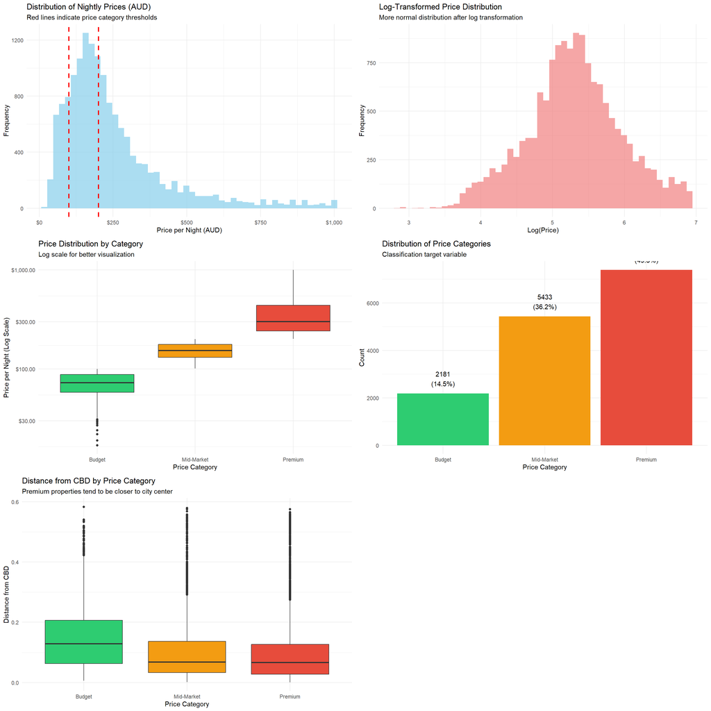

```r
# 1. Price distribution plots
p1 <- ggplot(listings, aes(x = price_numeric)) +
  geom_histogram(bins = 50, fill = "skyblue", alpha = 0.7) +
  geom_vline(xintercept = c(100, 200), color = "red", linetype = "dashed", size = 1) +
  labs(title = "Distribution of Nightly Prices (AUD)",
       subtitle = "Red lines indicate price category thresholds",
       x = "Price per Night (AUD)", y = "Frequency") +
  theme_minimal() +
  scale_x_continuous(labels = dollar_format(prefix = "$"))
# Log-transformed price for better visualization
p2 <- ggplot(listings, aes(x = log(price_numeric))) +
  geom_histogram(bins = 50, fill = "lightcoral", alpha = 0.7) +
  labs(title = "Log-Transformed Price Distribution",
       subtitle = "More normal distribution after log transformation",
       x = "Log(Price)", y = "Frequency") +
  theme_minimal()

# Price by category
p3 <- ggplot(listings, aes(x = price_category, y = price_numeric, fill = price_category)) +
  geom_boxplot() +
  scale_y_log10(labels = dollar_format(prefix = "$")) +
  labs(title = "Price Distribution by Category",
       subtitle = "Log scale for better visualization",
       x = "Price Category", y = "Price per Night (Log Scale)") +
  theme_minimal() +
  scale_fill_manual(values = c("Budget" = "#2ecc71", "Mid-Market" = "#f39c12", "Premium" = "#e74c3c")) +
  theme(legend.position = "none")

# Target distribution
p4 <- ggplot(listings, aes(x = price_category, fill = price_category)) +
  geom_bar() +
  geom_text(stat = 'count', aes(label = paste0(..count.., "\n(",
    round(..count../sum(..count..)*100, 1), "%)")), vjust = -0.5) +
  labs(title = "Distribution of Price Categories",
       subtitle = "Classification target variable",
       x = "Price Category", y = "Count") +
  theme_minimal() +
  scale_fill_manual(values = c("Budget" = "#2ecc71", "Mid-Market" = "#f39c12", "Premium" = "#e74c3c")) +
  theme(legend.position = "none")

# Distance from CBD analysis
p5 <- ggplot(listings, aes(x = price_category, y = distance_from_cbd, fill = price_category)) +
  geom_boxplot() +
  labs(title = "Distance from CBD by Price Category",
       subtitle = "Premium properties tend to be closer to city center",
       x = "Price Category", y = "Distance from CBD") +
  theme_minimal() +
  scale_fill_manual(values = c("Budget" = "#2ecc71", "Mid-Market" = "#f39c12", "Premium" = "#e74c3c")) +
  theme(legend.position = "none")

# Arrange plots
grid.arrange(p1, p2, p3, p4, p5, ncol=2)
```

## 5.2 Property Characteristics Analysis

**Show/Hide Code & Results**

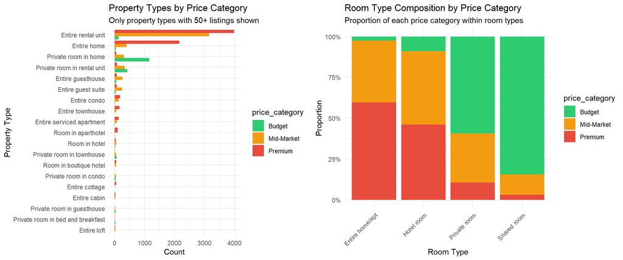

```r
# Property type analysis
p3 <- listings %>%
  count(property_type, price_category) %>%
  group_by(property_type) %>%
  filter(sum(n) >= 50) %>%     # keep property types with >= 50 listings
  ungroup() %>%
  ggplot(aes(x = reorder(property_type, n), y = n, fill = price_category)) +
  geom_bar(stat = "identity", position = "dodge") +
  coord_flip() +
  labs(title = "Property Types by Price Category",
       subtitle = "Only property types with 50+ listings shown",
       x = "Property Type", y = "Count") +
  theme_minimal() +
  scale_fill_manual(values = c("Budget" = "#2ecc71",
                               "Mid-Market" = "#f39c12",
                               "Premium" = "#e74c3c"))

# Room type analysis
p4 <- listings %>%
  ggplot(aes(x = room_type, fill = price_category)) +
  geom_bar(position = "fill") +
  labs(title = "Room Type Composition by Price Category",
       subtitle = "Proportion of each price category within room types",
       x = "Room Type", y = "Proportion") +
  theme_minimal() +
  scale_fill_manual(values = c("Budget" = "#2ecc71",
                               "Mid-Market" = "#f39c12",
                               "Premium" = "#e74c3c")) +
  scale_y_continuous(labels = scales::percent_format()) +
  theme(axis.text.x = element_text(angle = 45, hjust = 1))

# Arrange both plots
gridExtra::grid.arrange(p3, p4, ncol = 2)
```

## 5.3 Correlation Analysis

**Show/Hide Code & Results**

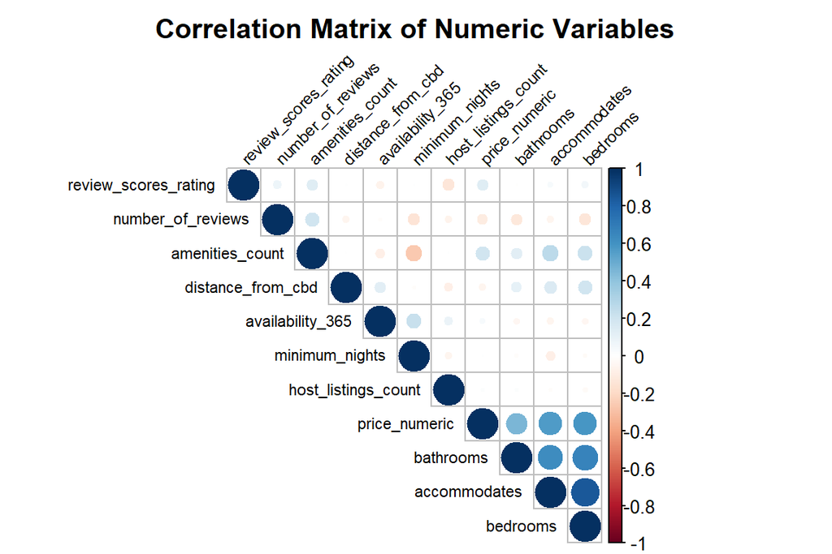

```r
# Selecting numeric variables for correlation analysis
numeric_data <- listings %>%
  select(price_numeric, accommodates, bedrooms, bathrooms, host_listings_count,
         number_of_reviews, review_scores_rating, availability_365,
         distance_from_cbd, amenities_count, minimum_nights) %>%
  filter(complete.cases(.))

# Calculate correlation matrix
correlation_matrix <- cor(numeric_data)

# Create correlation plot
corrplot(correlation_matrix, method = "circle", type = "upper",
         order = "hclust", tl.cex = 0.7, tl.col = "black",tl.srt = 45,mar = c(0, 0, 2, 0),
         title = "Correlation Matrix of Numeric Variables")
```

```r
# Display correlation table for key variables
key_correlations <- correlation_matrix["price_numeric", ] %>%
  sort(decreasing = TRUE) %>%
  round(3)

correlation_strings <- paste0(names(key_correlations), ": ", key_correlations)
cat("Correlation against Price: ","\n",(paste(correlation_strings, collapse=" | ")),"\n")
```

```
## Correlation against Price:
##  price_numeric: 1 | bedrooms: 0.581 | accommodates: 0.564 | bathrooms: 0.451 | amenities_count: 0.197 | review_scores_rating: 0.132 | availability_365: 0.037 | host_listings_count: 0.014 | minimum_nights: 0.005 | distance_from_cbd: -0.05 | number_of_reviews: -0.11
```

# 6 Modeling Plan

The modelling phase focuses on predicting Airbnb price categories using a classification approach (Inside Airbnb, 2025; Cox, 2024). To ensure robust results, five machine learning algorithms were selected that were discussed as part of the course. The dataset will be split into training and test sets, with cross-validation applied during training to minimize overfitting and improve generalization (Dhummad, 2025; Katyal, Sharma, & Kannan, 2025). Model performance will be assessed using multiple evaluation metrics - accuracy for overall correctness, precision and recall to capture domain performance, and macro or weighted F1-scores to account for potential class imbalance across the three price tiers. This comprehensive modeling plan balances interpretability with predictive accuracy, providing both actionable insights and reliable classification outcomes.

## 6.1 Selected Classification Models

We implement five classification ML algorithms, prioritizing methods taught in STAT5003 class to predict Sydney Airbnb price categories.

| Model | Purpose | Strengths | Use Case | Rationale for Dataset |
| --- | --- | --- | --- | --- |
| Multinomial Logistic Regression | Baseline interpretable model | Interpretable, fast, probability outputs | Linear relationships | Provides transparent baseline for feature contributions |
| Random Forest | Ensemble method | Handles mixed data, resistant to overfitting, feature importance | Captures non-linear relationships | Handles categorical & numerical features, identifies key drivers |
| Support Vector Machine | High-dimensional classification | Robust to outliers, flexible boundaries | Complex decision boundaries | Separates overlapping price categories using kernels |
| Linear Discriminant Analysis | Dimensionality reduction | Simple, interpretable, efficient | Maximize class separation | Reduces redundancy in correlated features |
| K Nearest Neighbors | Non-parametric, instance-based | Simple, local pattern recognition | Geographic/neighborhood patterns | Leverages localized pricing similarity |

## 6.2 Model Implementation Strategy

1. **Baseline Models (Logistic Regression, LDA):**
   - Establish performance benchmark
   - Identify most important linear predictors
   - Provide interpretable coefficients
2. **Tree-based Model (Random Forest):**
   - Capture non-linear relationships
   - Handle feature interactions automatically
   - Provide feature importance rankings
3. **Distance-based Model (KNN):**
   - Leverage geographic clustering
   - Capture local neighborhood effects
   - Non-parametric approach
4. **Kernel Method (SVM):**
   - Complex decision boundaries
   - Robust to outliers
   - High-dimensional feature space
5. **Model Comparison:**
   - Statistical significance testing
   - Computational efficiency analysis
   - Error pattern analysis
   - Business interpretation of results

## 6.3 Model Evaluation Framework

### 6.3.1 Data Splitting Strategy

The Sydney Airbnb dataset can be split in 70% training data and 30% test data. We can split the dataset into training and testing sets to ensure that our classification models learn patterns effectively and can generalize well into new and unseen data.

**Show/Hide Code & Results**

```r
library(caret)
# Stratified train-test split ratio (70:30)
set.seed(123)
train_indices <- createDataPartition(listings$price_category, p = 0.7, list = FALSE)
train_data <- listings[train_indices, ]
test_data <- listings[-train_indices, ]

# Compute sizes and percentages
train_size <- nrow(train_data)
test_size <- nrow(test_data)
train_pct <- round(train_size / nrow(listings) * 100, 1)
test_pct <- round(test_size / nrow(listings) * 100, 1)

# Class distributions
train_dist <- round(prop.table(table(train_data$price_category)), 3)
test_dist <- round(prop.table(table(test_data$price_category)), 3)

output_text <- paste0(
  "Data Splitting Summary:\n",
  "Training set size: ", train_size, " (", train_pct, "%)\n",
  "Test set size    : ", test_size, " (", test_pct, "%)\n\n",
  "Class distribution in training set:\n",
  paste(names(train_dist), ":", train_dist, collapse = "\n"), "\n\n",
  "Class distribution in test set:\n",
  paste(names(test_dist), ":", test_dist, collapse = "\n"), "\n"
)

cat(output_text)
```

```
## Data Splitting Summary:
## Training set size: 10507 (70%)
## Test set size    : 4500 (30%)
##
## Class distribution in training set:
## Budget : 0.145
## Mid-Market : 0.362
## Premium : 0.493
##
## Class distribution in test set:
## Budget : 0.145
## Mid-Market : 0.362
## Premium : 0.493
```

### 6.3.2 Cross-Validation Strategy

- **Method**: 5-fold cross-validation on training set
- **Repetitions**: 3 repetitions for robust estimates
- **Stratification**: Maintain class proportions within each fold

### 6.3.3 Evaluation Metrics

Our comprehensive evaluation metrics can be classified under the following categories:

**1. Overall Performance Metrics**

- **Accuracy**: Proportion of correctly classified instances
- **Kappa Statistic**: Agreement between predicted and actual classifications (accounting for chance)
2. **Class-Specific Metrics**
- **Precision**: True Positives / (True Positives + False Positives)
- **Recall (Sensitivity)**: True Positives / (True Positives + False Negatives)
- **F1-Score**: Harmonic mean of Precision and Recall
- **Specificity**: True Negatives / (True Negatives + False Positives)
3. **Multi-Class Extensions**
- **Macro-averaged metrics**: Average metrics across all classes
- **Weighted-averaged metrics**: Class-size weighted averages
- **Confusion Matrix**: Detailed classification breakdown
4. **Advanced Metrics**
- **Area Under ROC Curve (AUC)**: For each class vs. rest
- **Log-Loss**: Probabilistic classification error
- **Balanced Accuracy**: Average of class-specific accuracies

### 6.3.4 Feature Engineering for Models

**Show/Hide Code & Results**

```r
# Prepare features for modeling
prepare_features <- function(data) {
  model_data <- data %>%
    select(
      # Numeric features
      accommodates, bedrooms, bathrooms, host_listings_count,
      number_of_reviews, review_scores_rating, availability_365,
      minimum_nights, distance_from_cbd, amenities_count,

      # Categorical features
      property_type, room_type, neighbourhood_cleansed,
      host_is_superhost, host_identity_verified,
      is_popular_area, property_size, host_experience,
      availability_level,

      # Target variable
      price_category
    ) %>%
    na.omit()  # Remove any remaining missing values
  return(model_data)
}

# Preparing train and test datasets
train_features <- prepare_features(train_data)
test_features <- prepare_features(test_data)

# Get feature names excluding target variable
feature_names <- names(train_features)[names(train_features) != "price_category"]

# Feature type summary
feature_types <- train_features %>%
  select(-price_category) %>%
  summarise_all(~ifelse(is.numeric(.), "Numeric", "Categorical")) %>%
  gather(Feature, Type) %>%
  count(Type)

# Format feature summary as text
feature_summary_text <- paste0(feature_types$Type, ": ", feature_types$n, collapse = ", ")

# Format feature names as single line with pipes
feature_names_text <- paste(feature_names, collapse = " | ")

cat(
  "Feature Preparation Summary:\n",
  "Training features shape: ", dim(train_features)[1], " rows x ", dim(train_features)[2], " columns\n",
  "Test features shape    : ", dim(test_features)[1], " rows x ", dim(test_features)[2], " columns\n",
  "Number of features for modeling (excluding target): ", ncol(train_features) - 1, "\n\n",
  "Feature type summary: ", feature_summary_text, "\n\n",
  "The 19 features for modeling:\n",
  feature_names_text, "\n"
)
```

```
## Feature Preparation Summary:
##  Training features shape:  10507  rows x  20  columns
##  Test features shape    :  4500  rows x  20  columns
##  Number of features for modeling (excluding target):  19
##
##  Feature type summary:  Categorical: 9, Numeric: 10
##
##  The 19 features for modeling:
##  accommodates | bedrooms | bathrooms | host_listings_count | number_of_reviews | review_scores_rating | availability_365 | minimum_nights | distance_from_cbd | amenities_count | property_type | room_type | neighbourhood_cleansed | host_is_superhost | host_identity_verified | is_popular_area | pro…
```

- The initial dataset consisted of 20 features, including 12 numeric (such as id, accommodates, bedrooms, bathrooms, latitude, longitude, host_listings_count, review_scores_rating, number_of_reviews, reviews_per_month, availability_365, and minimum_nights), 6 character (price, property_type, room_type, amenities, neighbourhood_cleansed, and host_response_rate), and 2 boolean variables (host_is_superhost and host_identity_verified).
- From these, 8 additional features were engineered: price_numeric and price_category from price, amenities_count from amenities, is_popular_area from neighbourhood_cleansed, distance_from_cbd from latitude and longitude, host_experience from host_listings_count, property_size from accommodates, and availability_level from availability_365.
- For machine learning modeling, we finalized 19 predictive features—accommodates, bedrooms, bathrooms, host_listings_count, number_of_reviews, review_scores_rating, availability_365, minimum_nights, distance_from_cbd, amenities_count, property_type, room_type, neighbourhood_cleansed, host_is_superhost, host_identity_verified, is_popular_area, property_size, host_experience, and availability_level—with the target variable defined as price_category (Budget, Mid-Market, Premium).

### 6.3.5 Hyperparameter Tuning Strategy

Each model will undergo systematic hyperparameter optimization to select the best performing parameters:

1. **Random Forest**
- `ntree`: Number of trees (500, 1000, 1500)
- `mtry`: Variables per split (sqrt(p), p/3, p/2)
- `nodesize`: Minimum node size (1, 5, 10)
2. **Linear Discriminant Analysis**
- `prior`: Prior probabilities (equal, proportional to class frequencies, custom)
- `method`: Estimation method (moment, mle, mve, t)
- `nu`: Degrees of freedom for method=“t” (5, 10, 20)
- `tol`: Tolerance for rank deficiency (1e-4, 1e-6, 1e-8)
3. **Support Vector Machine**
- `cost`: Regularization parameter (0.1, 1, 10, 100)
- `kernel`: Kernel type (linear, radial, polynomial)
- `gamma`: Kernel coefficient (0.001, 0.01, 0.1, 1)
4. **K Nearest Neighbors**
- `k`: Number of neighbors (3, 5, 7, 9, 11, 15)
- Distance metric: Euclidean, Manhattan
- Scaling: Standardized vs. normalized features

# 7 Introduced Business Innovation and Expected Outcomes

1. **Predictive Insights:**
   - Identify key drivers of premium pricing in Sydney area
   - Quantify impact of location vs. property characteristics on the nightly prices
   - Understand host quality impact on pricing inflation
2. **Market Segmentation:**
   - Clear classification of Sydney accommodation market
   - Neighborhood-specific pricing pattern variations
   - Property type optimization strategies
3. **Policy Implications:**
   - Evidence for short-term rental regulations
   - Impact assessment on Sydney housing affordability and crisis
   - Tourism industry planning insights and annual budgeting
4. **Business Applications:**
   - Investment guidance for property owners
   - Pricing optimization for hosts
   - Market entry strategies for new listings
5. **Technical Contributions:**
   - Comparative analysis of ML algorithms on Sydney data
   - Feature importance insights for accommodation pricing
   - Geographic modeling approaches for real estate markets

# 8 Conclusion

This analysis establishes a robust foundation for understanding Sydney’s short-term rental market through the lens of data science. Our comprehensive examination of 15,000+ Airbnb properties reveals clear market segmentation patterns that reflect broader Australian housing dynamics.

# 9 Appendix

## 9.1 References

1. Inside Airbnb. (2025). Sydney, New South Wales, Australia Dataset. Retrieved from http://insideairbnb.com/get-the-data/
2. Cox, M. (2024). Inside Airbnb: Adding Data to the Debate. Retrieved from http://insideairbnb.com/about.html
3. Australian Bureau of Statistics. (2023). Housing Occupancy and Costs. Retrieved from https://www.abs.gov.au/
4. NSW Government. (2024). Short-term Rental Accommodation Industry in NSW. Retrieved from https://www.nsw.gov.au/
5. James, G., Witten, D., Hastie, T., & Tibshirani, R. (2021). An Introduction to Statistical Learning with Applications in R (2nd ed.). Springer.
6. Dhummad, S. (2025). The Imperative of Exploratory Data Analysis in Machine Learning. Scholars Journal of Engineering and Technology, 13.
7. Katyal, A., Sharma, P. K., & Kannan, M. (2025). Exploratory Data Analysis (EDA) on Undergraduate Data Science Students Through R Programming.
8. Michelucci, U. (2025). Data Visualisation. In Statistics for Scientists: A Concise Guide for Data-driven Research (pp. 109-119). Cham: Springer Nature Switzerland.

## 9.2 Data Dictionary

**Show/Hide Code & Results**

```r
# Creating a comprehensive data dictionary
data_dict <- data.frame(
  Variable = c("price_category", "accommodates", "bedrooms", "bathrooms",
               "property_type", "room_type", "neighbourhood_cleansed",
               "latitude", "longitude", "host_is_superhost", "host_response_rate",
               "host_listings_count", "review_scores_rating", "number_of_reviews",
               "availability_365", "minimum_nights", "amenities_count",
               "distance_from_cbd", "is_popular_area", "property_size"),

  Type = c("Categorical", "Numeric", "Numeric", "Numeric",
           "Categorical", "Categorical", "Categorical",
           "Numeric", "Numeric", "Logical", "Numeric",
           "Numeric", "Numeric", "Numeric",
           "Numeric", "Numeric", "Numeric",
           "Numeric", "Logical", "Categorical"),

  Description = c("Target variable: Budget (<$100), Mid-Market ($100-200), Premium (>$200)",
                  "Maximum number of guests property can accommodate",
                  "Number of bedrooms available",
                  "Number of bathrooms available",
                  "Type of property (Apartment, House, etc.)",
                  "Type of rental (Entire home, Private room, Shared room)",
                  "Sydney neighbourhood/suburb name",
                  "Geographic latitude coordinate",
                  "Geographic longitude coordinate",
                  "Whether host has Superhost status",
                  "Host response rate as proportion (0-1)",
                  "Number of listings managed by host",
                  "Average review score rating (1-5 scale)",
                  "Total number of reviews received",
                  "Days available for booking per year",
                  "Minimum nights required for booking",
                  "Number of amenities provided",
                  "Calculated distance from Sydney CBD",
                  "Whether in popular tourist area",
                  "Property size category based on capacity")
)

kable(data_dict, caption = "Complete Data Dictionary for Model Features")
```

Complete Data Dictionary for Model Features

| Variable | Type | Description |
| --- | --- | --- |
| price_category | Categorical | Target variable: Budget (<$100), Mid-Market ($100-200), Premium (>$200) |
| accommodates | Numeric | Maximum number of guests property can accommodate |
| bedrooms | Numeric | Number of bedrooms available |
| bathrooms | Numeric | Number of bathrooms available |
| property_type | Categorical | Type of property (Apartment, House, etc.) |
| room_type | Categorical | Type of rental (Entire home, Private room, Shared room) |
| neighbourhood_cleansed | Categorical | Sydney neighbourhood/suburb name |
| latitude | Numeric | Geographic latitude coordinate |
| longitude | Numeric | Geographic longitude coordinate |
| host_is_superhost | Logical | Whether host has Superhost status |
| host_response_rate | Numeric | Host response rate as proportion (0-1) |
| host_listings_count | Numeric | Number of listings managed by host |
| review_scores_rating | Numeric | Average review score rating (1-5 scale) |
| number_of_reviews | Numeric | Total number of reviews received |
| availability_365 | Numeric | Days available for booking per year |
| minimum_nights | Numeric | Minimum nights required for booking |
| amenities_count | Numeric | Number of amenities provided |
| distance_from_cbd | Numeric | Calculated distance from Sydney CBD |
| is_popular_area | Logical | Whether in popular tourist area |
| property_size | Categorical | Property size category based on capacity |

## 9.3 Extra Graphs

**Geographic Analysis**

**Show/Hide Code & Results**

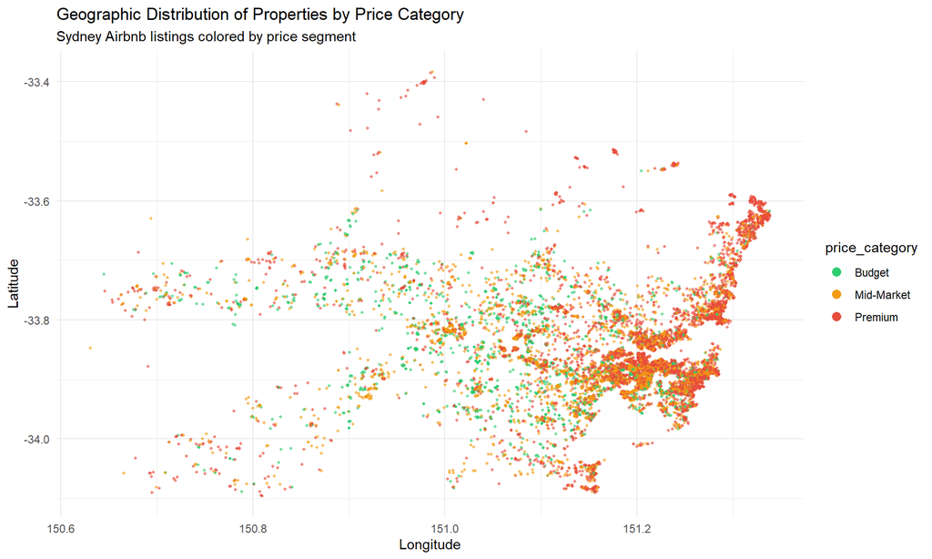

```r
# Geographic distribution
ggplot(listings, aes(x = longitude, y = latitude, color = price_category)) +
  geom_point(alpha = 0.6, size = 0.8) +
  labs(title = "Geographic Distribution of Properties by Price Category",
       subtitle = "Sydney Airbnb listings colored by price segment",
       x = "Longitude", y = "Latitude") +
  theme_minimal() +
  scale_color_manual(values = c("Budget" = "#2ecc71", "Mid-Market" = "#f39c12", "Premium" = "#e74c3c")) +
  guides(color = guide_legend(override.aes = list(size = 3, alpha = 1)))
```

**Neighbourhood Analysis**

**Show/Hide Code & Results**

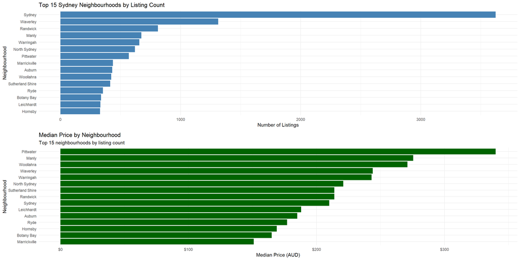

```r
# Top neighbourhoods by count
top_neighbourhoods <- listings %>%
  count(neighbourhood_cleansed, sort = TRUE) %>%
  head(15)

p7 <- ggplot(top_neighbourhoods, aes(x = reorder(neighbourhood_cleansed, n), y = n)) +
  geom_col(fill = "steelblue") +
  coord_flip() +
  labs(title = "Top 15 Sydney Neighbourhoods by Listing Count",
       x = "Neighbourhood", y = "Number of Listings") +
  theme_minimal()

# Median price by neighbourhood
neighbourhood_price <- listings %>%
  filter(neighbourhood_cleansed %in% top_neighbourhoods$neighbourhood_cleansed) %>%
  group_by(neighbourhood_cleansed) %>%
  summarise(
    count = n(),
    median_price = median(price_numeric),
    premium_pct = mean(price_category == "Premium") * 100
  ) %>%
  arrange(desc(median_price))

p8 <- ggplot(neighbourhood_price, aes(x = reorder(neighbourhood_cleansed, median_price),
                                     y = median_price)) +
  geom_col(fill = "darkgreen") +
  coord_flip() +
  labs(title = "Median Price by Neighbourhood",
       subtitle = "Top 15 neighbourhoods by listing count",
       x = "Neighbourhood", y = "Median Price (AUD)") +
  theme_minimal() +
  scale_y_continuous(labels = dollar_format(prefix = "$"))

grid.arrange(p7, p8, ncol = 1)
```

*This analysis was conducted as part of STAT5003 Computational Statistical Methods coursework, focusing on real-world application of machine learning techniques to Australian housing market data. The report has been prepared with the assistance of artificial intelligence (AI) tools. AI was used to support tasks such as research support, grammar correction and clarity improvement. All content has been reviewed and verified by the team to ensure accuracy, relevance and alignment with project objectives.*